# Lab 3: Segmentation, Thresholding, and Region Growing

# Jonathan Ananda Nusantara (jan265)

### Section 2: Peakiness Detection (vtpeakpy)

In section 2, the task is to explore a python program called vtpeakpy. Vtpeakpy is a automatic thresholding python program which will accept an image input and output the thresholded image. The algorithm is that it will detect two of the main peaks in the histogram of the input image and the threshold will be the lowest minimum histogram value between the two histogram peaks. Another input to the program is the "d" parameter, which stands for the minimum histogram bins distance between the two peaks. This is to prevent the second largest histogram value to be the one next to it, which would cause an inaccurate threshold selection. The vtpeakpy program is tested on 4 different images: mp.vx, facsimile, map, and shtl.vx. The input and output images are displayed and discussed below:

```python
import sys
import numpy as np
from numpy import *
# from v4 import vx
import matplotlib.pyplot as plt
import matplotlib.cm as cm
from PIL import Image
from IPython.display import display
```

The vtpeakpy program is tested in all four images above and their output is shown right below the original image. For each of the images, several "d" parameter are tested to make sure that thresholded most accurately. Choosing the right "d" value may be tricky, but this is done by referring to the histogram. The histogram can be accessed through "Tools -> Image Histogram" in vview. From the image histogram, we can see the two peaks of the bimodal histogram with a deep valley in between. If a distance is not chosen right or is too small, the second highest bin may still be in the same peak region of the bimodal histogram. As a result, the threshold chosen by the algorithm may not be ideal and the output thresholded image produced may not be good.

The first test image that was used is the map image. In order to best segment the image, the right "d" input needs to be found. The first step is to analyze the histogram (shown in Figure 1). From the histogram, we can see that the two peaks of the bimodal histogram are at around pixel value of 40 and 130. The valley between the two peaks is at around 60. In order to achieve the next max bin to be around 40, instead of still in the region of 130, a larger "d" needs to be chosen. After trials and errors, a "d" value of 70 is chosen and the threshold used is 64, which will be the optimal value from this algorithm. This technique of choosing the "d" value based on the histogram is being done for all of the test images.

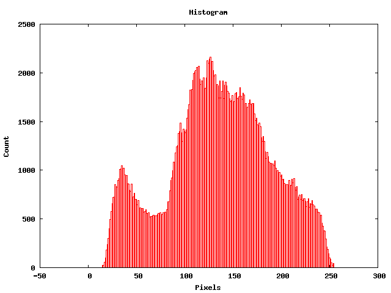

[output not shown]

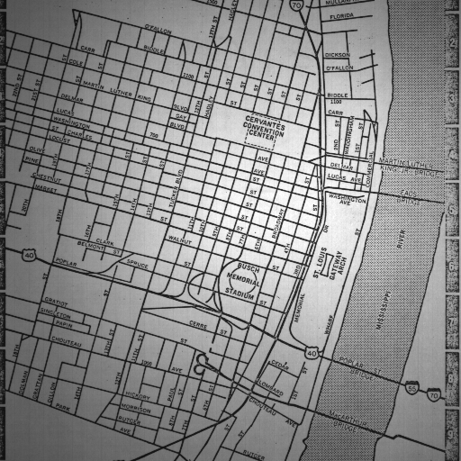

```
Figure 2 - original image of map.vx
```

[figure not shown]

```
Figure 3 - thresholded image of map.vx with d=70, threshold at 64
```

```python
display(Image.open("map-hist.png"))
print("Figure 1 - histogram of mp.vx \n\n")

display(Image.open("map.png"))
print("Figure 2 - original image of map.vx \n\n")
display(Image.open("map-2.png"))
print("Figure 3 - thresholded image of map.vx with d=70, threshold at 64 \n\n")
```

For the map image in Figure 2, the best distance input to be used is 70. The output shown in Figure 3 shows the thresholded image, and unfortunately the outer part of the map is blacked out. This is because the outer part of the original image is a bit darker. This may be caused by an illumination variation in the original image. Due to the condition of the original image, it cannot be segmented well because a single threshold value will not work for the entire image.

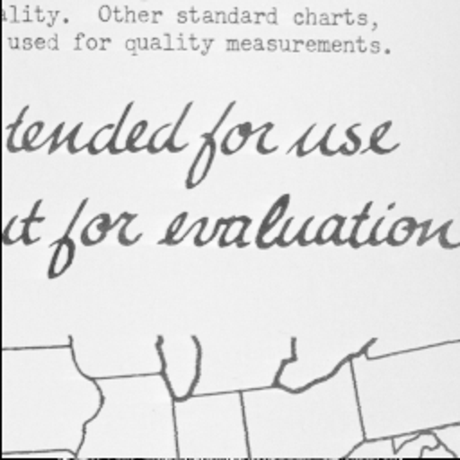

```
Figure 4 - original image of facsimile.vx
```

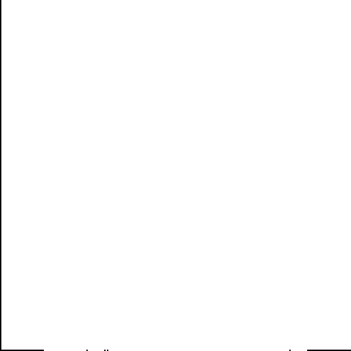

```
Figure 5 - thresholded image of facsimile.vx with d=20, threshold at 1
```

```python
im = Image.open("facsimile.png")
width, height = im.size
im = im.resize((width*2, height*2))
display(im)
print("Figure 4 - original image of facsimile.vx \n\n")
im = Image.open("facsimile-2.png")
width, height = im.size
im = im.resize((width*2, height*2))
display(im)
print("Figure 5 - thresholded image of facsimile.vx with d=20, threshold at 1 \n\n")
```

For the Facsimile image in Figure 4, the output was not able to be generated well. This is because when distance input is chosen as 10, it will choose a very high threshold that makes almost the entire image black. When a distance is set to around 20, the threshold will be 1 and the entire image would be white. This may be because the histogram of this image contains a lot of empty histogram bins and as a result the algorithm does not have enough data to choose the ideal threshold value for the image.

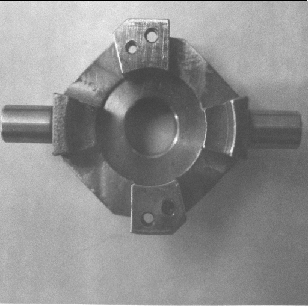

```
Figure 6 - original image of mp.vx
```

[figure not shown]

```
Figure 7 - thresholded image of mp.vx with d=10, threshold at 83
```

```python
display(Image.open("mp.png"))
print("Figure 6 - original image of mp.vx \n\n")
display(Image.open("mp-2.png"))
print("Figure 7 - thresholded image of mp.vx with d=10, threshold at 83 \n\n")
```

[output not shown]

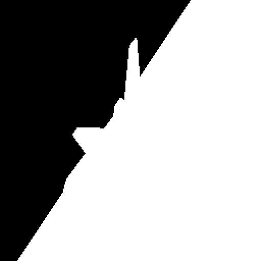

```
Figure 9 - thresholded image of shtl.vx with d=40, threshold at 112
```

```python
im = Image.open("shtl.png")
width, height = im.size
im = im.resize((width*2, height*2))
display(im)
print("Figure 8 - original image of shtl.vx \n\n")
im = Image.open("shtl-2.png")
width, height = im.size
im = im.resize((width*2, height*2))
display(im)
print("Figure 9 - thresholded image of shtl.vx with d=40, threshold at 112 \n\n")
```

For the shuttle image in Figure 8, the output that is generated is not too good. As the shuttle object of the original image is of a single grey color with a gradient background ranging from black to white, when the threshold is chosen, the output will result to the shuttle object to be of the same color of one side of the background. In this case shown in Figure 9, we can see that the shuttle from the output image is colored white and you are not able to tell the region difference with the background on the right side of the image. We can conclude that the image is not segmented well.

### Section 3: Iterative Threshold Selection (vits)

In section 3, the task is to create an automatic thresholding program that will perform an iterative thresholding. This program will be named vits and it will be built off the code of vtpeakpy but with several changes. The way this iterative algorithm works is that it will first either receive an initial threshold to try from the user or it will calculate a threshold value from the average gray value of the entire image. Then, the histogram will be separated into two different regions and an average or mean gray value for each region is calculated. Then, the average between these two averages will be used as the new threshold value. This algorithm will continue to iterate until the average of the two regions or the threshold calculation no longer changes. This means that the threshold calculation has converged to an optimal point. Since the threshold value is derived from the averages across the entire histogram, this means that the entire image data is being considered for this threshold calculation, allowing a more robust algorithm.

Since this is an iterative algorithm, a while loop is used to perform this iterative calculations. This while loop will continue executing while the previous and current average value calculation of the two regions still changes. In order to do this, a total of four variables are used to store the average values: a previous and current average value for each of the region. Going into the loop, the first step is to update the previous average variable with the current value. Then, a midpoint is defined as the rounded up value of the threshold value. It is rounded up as it may be a float number. Using the midpoint value, two average values of the two regions are calculated using the "average" function that has been programmed. One region will go form 0 to the midpoint and the other will go from midpoint to value of 255. From the two averages calculated, the threshold value for the iteration will be the average of the two. This iteration will continue until the threshold value converges to an ontimum value. At the end of the program, similar to the vtpeakpy, an iteration through all pixels are done to change their values to either 0 or 255 based on the threshold value.

The code for vits python program is below:

```python
#!/usr/bin/env python

"""
vits:  Iterative threshold selection algorithm
"""

import sys
import numpy as np
from numpy import *
from v4 import vx
import math

of=' '
vxif=' '
clist = vx.vxparse(sys.argv, "if= of= t= -v -")
exec (clist)

if 'OPT' in locals():
   print ("vits: iterative threshold selection algorithm")
   print ("if= input file")
   print ("of= output file")
   print ("t=  initial threshold (default is average gray value)")
   print ("-v  (verbose) print threshold information")
   exit(0)

optv = 'OPTv' in locals()

inimage = vx.Vx(vxif)
im = inimage.i
if im.dtype != uint8 :
    print ("error: image not byte type", file=sys.stderr)
    exit(1)

thresh = 0

if 't' in locals():
  t_in = int(t)
  if t_in < 0 or t_in > 255:
      print("t= must be between 0 and 255", file=sys.stderr)
  else: # If threshold input is suitable, use it
	  thresh = t_in
else: # If threshold is not defined by user
    total_pixel_value = 0
    pixel_count = 0
    for y in range(im.shape[0]):
        for x in range(im.shape[1]):
            total_pixel_value = total_pixel_value + im[y,x]
            pixel_count = pixel_count + 1
    thresh = total_pixel_value / pixel_count

# Create a blank histogram of 256 bins
hist = np.zeros(256)

# Compute the histogram
for y in range(im.shape[0]):
  for x in range(im.shape[1]):
    hist[im[y,x]]+=1

# Function to calculate average gray values between hist range
def average (low, high):
    ave = 0
    total_mult = 0
    total_pix = 0

    for i in range(low, high):
        total_mult = total_mult + (hist[i] * i)
        total_pix = total_pix + hist[i]

    ave = total_mult / total_pix
    return ave

avg1 = 0
avg2 = 0
old1 = 1 # Differentiate to avg values to enter loop
old2 = 1

# Loop to determine threshold
while avg1 != old1 and avg2 != old2: # stop if avg1 and 2 is already equal
	# Update old average values
	old1 = avg1
	old2 = avg2

	# Determine the splitting value for histogram regions
	midpoint = math.ceil(thresh) # Round up

	# Calculate average gray values of the two regions
	avg1 = average(0, midpoint)
	avg2 = average(midpoint, 256)
	print(midpoint, avg1, avg2, thresh)
	# New thresh value
	thresh = (avg1 + avg2) / 2

# Print output for verbose mode
if (optv):
  print("thresh=",thresh, file=sys.stderr)

# Apply threshold
for y in range(im.shape[0]):
  for x in range(im.shape[1]):
    if (im[y,x] >= thresh):
      im[y,x] = 255
    else:
      im[y,x] = 0

vx.vfwrite(of, im)
```

This vits program is first tested on 3 different small images to verify that it performs as expected. These small iamges are designed to test the edge cases, such as when several main objects are connected or objects are in the edges of the images. The first test small image is smallima.vx (shown in Figure 10 as a .png image).

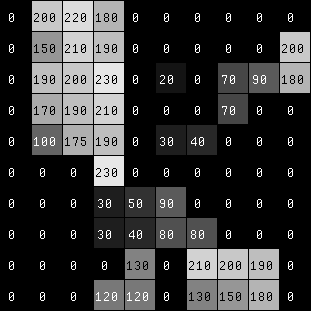

```
Figure 10 - original image of smallima.vx
```

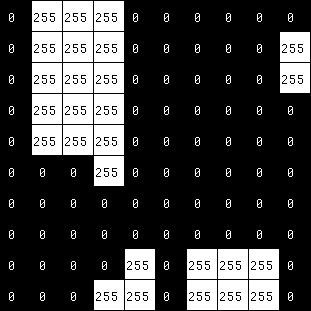

```
Figure 11 - thresholded image of smallima.vx with threshold=94
```

```python
display(Image.open("smallima.png"))
print("Figure 10 - original image of smallima.vx \n\n")
display(Image.open("smallima-3.png"))
print("Figure 11 - thresholded image of smallima.vx with threshold=94 \n\n")
```

The vits program will first calculate an initial threshold value since none is provided. Then it will create the histogram and iteratively calculate the threshold value based on the average of the two histogram regions based on the previous threshold value. The threshold value will eventually converge and the iteration will stop. The output small test image is the thresholded image. Looking at the result in Figure 11, it looks like the image is segmented well. The image is thresholded with the value of 94. The higher valued pixels from Figure 10 now has the value of 255 while the lower valued pixels now became 0. We can see clearly see the different regions in the image.

The next test images tested are smallimb.vx and smallimc.vx (shown in Figure 12 and 14 as a .png image).

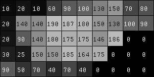

[output not shown]

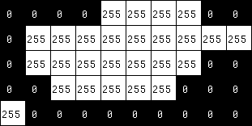

```
Figure 13 - thresholded image of smallimb.vx with threshold=86
```

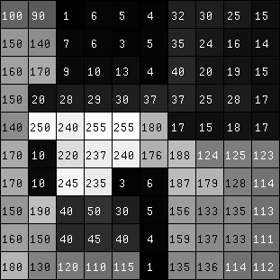

```
Figure 14 - original image of smallimc.vx
```

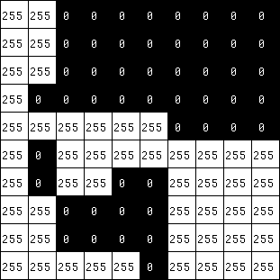

```
Figure 15 - thresholded image of smallimc.vx with threshold=90
```

```python
display(Image.open("smallimb.png"))
print("Figure 12 - original image of smallimc.vx \n\n")
display(Image.open("smallimb-3.png"))
print("Figure 13 - thresholded image of smallimb.vx with threshold=86 \n\n")

display(Image.open("smallimc.png"))
print("Figure 14 - original image of smallimc.vx \n\n")
display(Image.open("smallimc-3.png"))
print("Figure 15 - thresholded image of smallimc.vx with threshold=90 \n\n")
```

Based on the vits algorithm, the image smallimb.vx has a threshold value of 86 while image smallimc.vx has a threshold value of 90. From the results in Figure 13 and 15, we can see that the images are segmented well and we can see the different regions of the image. Concluding based on the results from the three small test images, the algorithm works really well.

Now that the program has been verified to work in test images, the program will now be tested on the large images. This will clearly show the performance of this algorithm compared to others (vtpeakpy). This program wil be tested against all four of the images used for vtpeakpy. The first test image used is the mp.vx image (Figure 16).

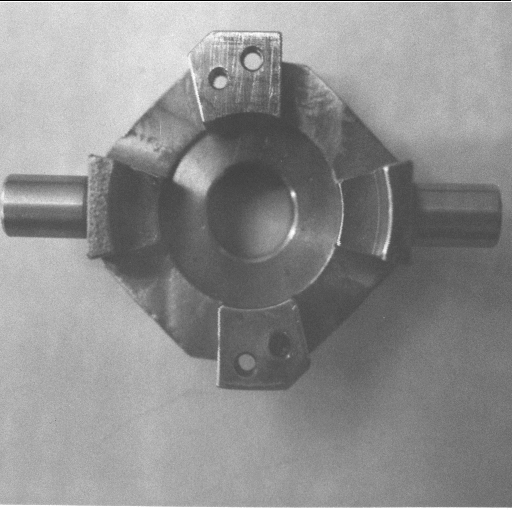

```
Figure 16 - original image of mp.vx
```

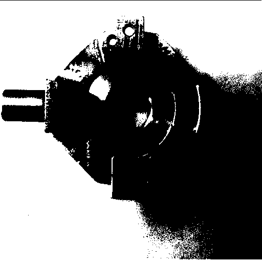

```
Figure 17 - thresholded image of mp.vx with threshold = 143
```

```python
display(Image.open("mp.png"))
print("Figure 16 - original image of mp.vx \n\n")
display(Image.open("mp-3.png"))
print("Figure 17 - thresholded image of mp.vx with threshold = 143\n\n")
```

Using the vits program, the mp.vx image is segmented using a threshold value of 143. This threshold value is calculated by considering the entire image data and through an iterative process to find the optimum threshold value. From the output image shown in Figure 17, we can sort of see the region of the object in the image that is segmented apart from the background, where the object is shown in black and the background in white. However, we can see how there are some bright pixels (value of 255) on the object itself and this is due to the uneven illumination of the original image (Figure 16). The right side of the background is also shown in black instead of white, which shows that this is not a perfect segmentation of image. Despite all these imperfections, the vits program has done a better job compared to the vtpeakpy program, in which we can better identify the region of the object.

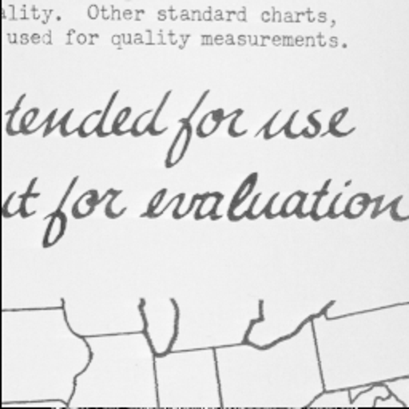

```
Figure 18 - original image of facsimile.vx
```

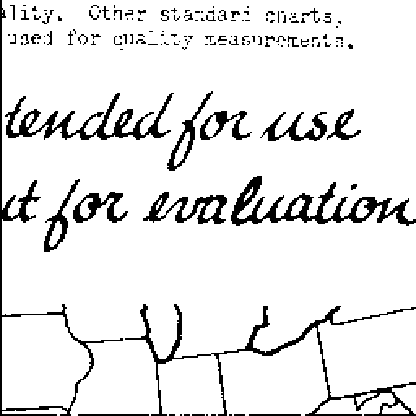

```
Figure 19 - thresholded image of facsimile.vx with threshold = 179
```

```python
im = Image.open("facsimile.png")
width, height = im.size
im = im.resize((width*2, height*2))
display(im)
print("Figure 18 - original image of facsimile.vx \n\n")
im = Image.open("facsimile-3.png")
width, height = im.size
im = im.resize((width*2, height*2))
display(im)
print("Figure 19 - thresholded image of facsimile.vx with threshold = 179\n\n")
```

The vits program segments the facsimile.vx image using a threshold value of 179. From the output shown in Figure 19, the image is segmented well and the main object can be easily identified. Compared to using vtpeakpy, the vits program has a much better performance. This may be because the vits program considers the entire image data and is not affected by empty histogram bins. This shows that when an has image empty histogram bins, the vits program or iterative threshold selectrion should be the preferred algorithm to vtpeakpy or peakiness detection.

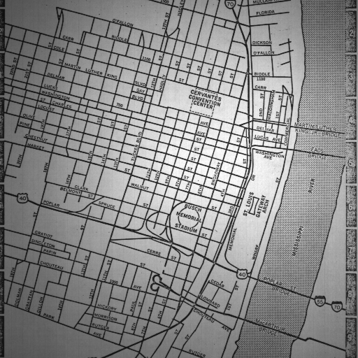

```
Figure 20 - original image of map.vx
```

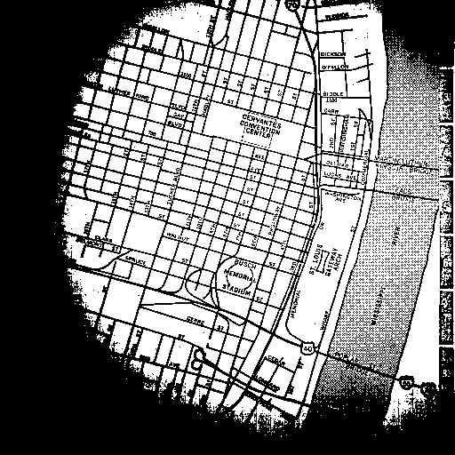

```
Figure 21 - thresholded image of map.vx with threshold = 135
```

```python
display(Image.open("map.png"))
print("Figure 20 - original image of map.vx \n\n")
display(Image.open("map-3.png"))
print("Figure 21 - thresholded image of map.vx with threshold = 135\n\n")
```

For the image map.vx, the vits program does not segment the image well, as shown in Figure 21. Due to the illumination variation of the original image, this thresholding method is not an ideal segmentation method for the image. Compared to the vtpeakpy program which is also an automatic thresholding method, there is no improvement in the result despite using a significantly different threshold value (135 vs 64). This again shows that no matter what threshold value is used for to segment the image, it will not make a difference. A single threshold will not work for this image. Perhaps an adaptive thresholding method may have a better performance as it will parse the image into different patches and use differnet threshold for each.

[output not shown]

[figure not shown]

```
Figure 23 - thresholded image of shtl.vx with threshold = 122
```

```python
im = Image.open("shtl.png")
width, height = im.size
im = im.resize((width*2, height*2))
display(im)
print("Figure 22 - original image of shtl.vx \n\n")
im = Image.open("shtl-3.png")
width, height = im.size
im = im.resize((width*2, height*2))
display(im)
print("Figure 23 - thresholded image of shtl.vx with threshold = 122\n\n")
```

The vits program segmented this image using a threshold value of 122. As shown in Figure 23, this image is not segmented well. The main object of the image, the shuttle, has the same pixel value of 255 to half of the background (the bottom-right portion of the background). This is because the background a gradient with the range from black to white, so no matter what threshold is chosen, the main object will have the same pixel value to some portion of the background. Both the vits and vtpeakpy program does not perform well and this may mean that automatic thresholding is not the method to go in segmenting this image. Other segmentation methods should be explored.

Based on the results of the vits program in processing all four large test images, we can see some improvements in segmentation performance compared to using vtpeakpy. The main reason would be because the vits algorithm will take the entire image data into account. This algorithm is more robust as it will tolerate more noise and is not affected with empty histogram bins. This is shown in the thresholding improvement in the mp.vx and facsimile.vx image. However, there are still limitations to this algorithm. Being an automatic thresholding algorithm, it still have a poor performance in segmenting an image with uneven illumination or touching objects. In the next sections of this lab, we will be exploring other segmentation methods that may have better performance in segmenting these images.

### Section 5: Region Growing (vgrow)

In section 5, another method of image segmentation is explored, which is region growing. In the previous sections it has been all about using thresholding for image segmentation. However, from the results above we can see that for some types of images using thresholding for image segmentation is not ideal. For those images, it may be better to use region growing.

Region growing is a method in which it will classify a group of pixels as a meaningful region if it passes the Homogeneity Criterion. This criteria may range from the grey level, or geometry (size and shape), or even topology. For the algorithm that is explored in this section, the criteria is the range of pixel value. The python program that will be created is vgrow. The algorithm will scan the entire image and group connected pixels that is within a pixel value range as a meaningful region. The output will be an image with the different regions. This program will be built based on the connected component labeling algorithm created in Lab2, which is cclabelpy. It will have a similar algorithm connected pixels and labeling them, but the program will not be making a distinction between foreground (pixel value above 0) or background (0-valued pixel), but will be classifying based on the pixel range and create regions from those information. Similar to cclabelpy program, this program will have a 4-foreground connectivity, in which the connected pixels that will be checked is only from four sides (top, bottom, left, and right).

This program will accept an integer "r" input from the user, which defines the pixel range to be used. This means that a group of connected pixels will be classified as a region if the deteced connected pixels are within this defined range to the first pixel detected. The user will also be able to choose between two labeling modes based on the "-p" input flag. If the "-p" flag is specified, the label of the region will be based on the first detected pixel value, which will allow the label to clearly represeng the region's pixel value. If the "-p" is not specified, then a sequential labeling pattern will be used (starting from 1, 2, 3...). One thing to note is that if the end of the label (255) has been reached, it will roll over to label 1.

Inside this program, there is a function definition "setlabel" that is adopted from "cclabelpy" program in Lab2. It accepts three parameters: "x" index, "y" index, and label number "n". This function will also read both the tm and im image, as well as the "first pixel" and "range" variables. The "first pixel" variable stores the pixel value of the first pixel detected for the region. This will be used along with the "range" variable as one of the criteria for the connected component labeling. This function will first set the label of the current pixel in the output im image. Then, it will attempt to recurse into 4 neighbours in the 4 sides (top, bottom, left, and right). Similar to the "cclabelpy" algorithm, the criteria is that the neigbour's pixel value needs to be above 0 and the pixel have not been labeled in the output image. However, there is another criteria that needs to be met for this algorithm. The difference between the neighbour pixel's value and the first pixel detected needs to be below the defined range allowed. If all three criteria are met, the recursive setlabel algorithm will be called into that neighbouring pixel. This function will be called in the main loop and it will recursively label all of connected pixels that passes the criteria with the same label.

The final section of this code is our main loop that iterates to every pixel in the original image (using embed image tm). There are two types of loops based on the "-p" flag: one that will label the region based on the first pixel and another that labels the region sequentially with a range from 1-255). In both cases, on every pixel, the loop will check on whether the current pixel has a value bigger than 0 and that it has not been labeled in the output im image. The "first pixel" variable will also be defined as the first pixel value detected. Then, the next part is where the "-p" flag came into effect. When "-p" flag is passed, the "label" passed into the "setlabel" function would be the "first pixel" value. Thus the output labels will be based on the first pixel value and would represeng the region well. On the other hand, when "-p" is not passed by the user, the label will start at 1, and it will be incremented for every region. This label will reset to 1 when it reaches the limit of 255. At the end of the day, the user will get to decide how they would want their image to be labeled. This would only change the label value and will not change the number of regions detected or the shape of each region.

This vgrow program, which is a region growing algorithm, is created to explore the performance of this type of image segmentation. The program will be tested with both small images and large images to test its edge cases. The result will be weighed the performance of this method.

The code for vgrow python program is below:

```python
#!/usr/bin/env python

""" vgrow a python region growing program
"""

import sys
from numpy  import *
from v4 import vx

of=' '
vxif=' '
clist = vx.vxparse(sys.argv,  "if= of= r= -p -v  - ")
exec (clist )

if 'OPT' in locals():
   print ("vgrow program")
   print ("if= input file")
   print ("of= output file")
   print ("r=  region pixel range")
   print ("-p  flag to select labeling scheme")
   print ("[-v] verbose mode")
   exit(0)

optp = 'OPTp' in locals()
optv = 'OPTv' in locals()

pixel_range = 0 # Initialize range variable
if 'r' in locals():
  print(r)
  r_in = int(r)
  if r_in < 0 or r_in > 255: # If r is not within range
      print("r= must be between 0 and 255", file=sys.stderr)
      pixel_range = 10 # Default range
  else: # If range input is suitable, use it
	  pixel_range = r_in

inimage = vx.Vx( vxif )
im = inimage.i
tmimage = vx.Vx( inimage )
tmimage.embedim((1,1,1,1))
tm = tmimage.i

# Clear image for output
for y in range(im.shape[0]):
    for x in range(im.shape[1]):
        im[y,x] = 0

first_pixel = 0 # Initialize variable to store value of first pixel

def setlabel (x, y, n): # n is current label
    global im, tm, first_pixel, r
    im[y,x] = n
    # 4 connected foreground 8 connected background
    if tm[y+2,x+1] > 0 and im[y+1,x] == 0 and (abs(int(tm[y+2,x+1]) - first_pixel) < pixel_range): # If pixel above current tm is foreground and not labeled in im
        setlabel(x, y+1, n)
    if tm[y,x+1] > 0 and im[y-1,x] == 0 and (abs(int(tm[y,x+1]) - first_pixel) < pixel_range): # If pixel below current tm is foreground and not labeled in im
        setlabel(x, y-1, n)
    if tm[y+1,x] > 0 and im[y,x-1] == 0 and (abs(int(tm[y+1,x]) - first_pixel) < pixel_range): # If pixel left of current tm is foreground and not labeled in im
        setlabel(x-1, y, n)
    if tm[y+1,x+2] > 0 and im[y,x+1] == 0 and (abs(int(tm[y+1,x+2]) - first_pixel) < pixel_range): # If pixel right current tm is foreground and not labeled in im
        setlabel(x+1, y, n)

l = 1 # Set initial label l to be 1
sys.setrecursionlimit(100000)
if optp:
    for y in range(im.shape[0]):
        for x in range(im.shape[1]):
            if tm[y+1,x+1] > 0 and im[y,x] == 0:
                first_pixel = int(tm[y+1,x+1]) # Set first pixel value
                setlabel(x, y, first_pixel)	# Use first pixel as label
else:
    for y in range(im.shape[0]):
        for x in range(im.shape[1]):
            if tm[y+1,x+1] > 0 and im[y,x] == 0:
                first_pixel = int(tm[y+1,x+1]) # Set first pixel value
                setlabel(x, y, l)
                l = l + 1 # Increment l for next label
                if l == 255: # If at max l value
                    l = 1 # Reset l to 1


if optv:
   print (im)

inimage.write(of)
```

This vgrow program is first tested on a set small image to verify that it performs as expected. These set images will test against the edge cases to test this program such as if there is a region inside another region, if a region is on the edge of the image, and also test the different types of connectivity.

The first test small image is smallimd.vx (shown in Figure 24 as a .png image). This smallimd has a total of 4 regions. It will test the edge case where there is a region inside another region. It will also test when the region is on the edge of the image. We will test if this program will perform as expected.

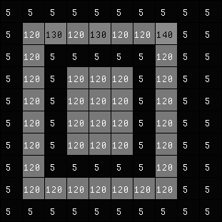

```
Figure 24 - original image of smallimd.vx
```

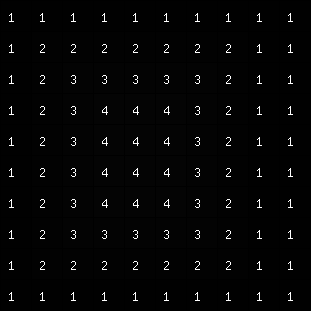

```
Figure 25 - output image of smallimd.vx from vgrow with range = 50
```

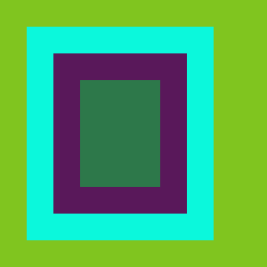

```
Figure 26 - output image of smallimd.vx from vgrow, with colored label using vcmap
```

```python
display(Image.open("smallimd.png"))
print("Figure 24 - original image of smallimd.vx \n\n")
display(Image.open("smallimd-5.png"))
print("Figure 25 - output image of smallimd.vx from vgrow with range = 50\n\n")
im = Image.open("smallimd-5-rand.png")
width, height = im.size
im = im.resize((width*30, height*30))
display(im)
print("Figure 26 - output image of smallimd.vx from vgrow, with colored label using vcmap\n\n")
```

Figure 24 is the input to the program. We can see that there would probably be a region that is enclosed by another region. Vgrow is performed on this image with no "-p" flag used and range is set to 50. With no "-p" flag, the labels will be in sequence starting from 1. As a result, we can see in Figure 25 that the output is of regions from 1 to 4. Since it is difficult to differentiate the regions in Figure 25, "vcmap lf=rand" command was performed on the output image to color the labels and the output is shown in Figure 26.

This next test will test the connectivity of the regions. This program is designed to have 4 connectivity foreground, so pixels will be considered connected only from the 4 sides (top, bottom, left, and right). This next test will confirm if this program would perform as expected.

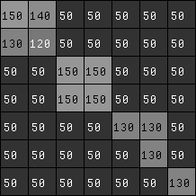

```
Figure 27 - original image of smallime.vx
```

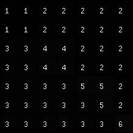

```
Figure 28 - output image of smallime.vx from vgrow with range = 50
```

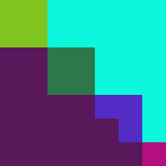

```
Figure 29 - output image of smallime.vx from vgrow, with colored label using vcmap
```

```python
display(Image.open("smallime.png"))
print("Figure 27 - original image of smallime.vx \n\n")
display(Image.open("smallime-5.png"))
print("Figure 28 - output image of smallime.vx from vgrow with range = 50\n\n")
im = Image.open("smallime-5-rand.png")
width, height = im.size
im = im.resize((width*30, height*30))
display(im)
print("Figure 29 - output image of smallime.vx from vgrow, with colored label using vcmap\n\n")
```

Figure 27 is the input to the vgrow program where the "-p" is not called and the range is set to 50. The original output is Figure 28, and Figure 29 has a colored label to allow a better visualization. From the result, we can see that there is a total of 6 regions. From the original image, we can see that there are regions of a similar range (within 50) that is connected by their corner points. If we are using 4 connectivity foreground, these regions will not be connected and will have different labels. If we are using 8 connectivity foreground, touching corners will be considered as connected. Based on the output in Figure 28 and 29, we confirmed that this program has a 4 connectivity foreground.

Next, the test image will test on what will happen if the image is reversed vertically. We are testing that it will still have the same regions and number of labels despite being reversed.

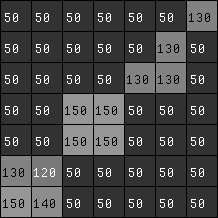

```
Figure 30 - original image of smallimf.vx
```

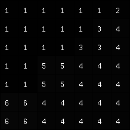

```
Figure 31 - output image of smallimf.vx from vgrow with range = 50
```

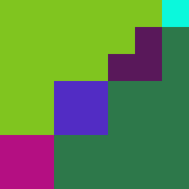

```
Figure 32 - output image of smallimf.vx from vgrow,  with colored label using vcmap
```

```python
display(Image.open("smallimf.png"))
print("Figure 30 - original image of smallimf.vx \n\n")
display(Image.open("smallimf-5.png"))
print("Figure 31 - output image of smallimf.vx from vgrow with range = 50\n\n")
im = Image.open("smallimf-5-rand.png")
width, height = im.size
im = im.resize((width*30, height*30))
display(im)
print("Figure 32 - output image of smallimf.vx from vgrow,  with colored label using vcmap\n\n")
```

Figure 30 is the input to vgrow program, and the output is shown in Figure 31, and the the labels are colored in Figure 32 for better visualization. From the result, we can see that the number of regions, their sizes and shape are consistent with Figure 28 and 29.

The last test image is to test the "-p" flag. This will make sure that the regions will be based on the first pixel detected.

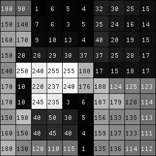

```
Figure 33 - original image of smallimc.vx
```

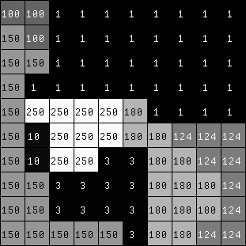

```
Figure 34 - output image of smallimc.vx from vgrow with range = 50, with -p flag
```

```python
display(Image.open("smallimc.png"))
print("Figure 33 - original image of smallimc.vx \n\n")
display(Image.open("smallimc-5.png"))
print("Figure 34 - output image of smallimc.vx from vgrow with range = 50, with -p flag \n\n")
```

From the two figures above, we can analyze that the output labels are based on the first pixel detected. For example, the very first pixel on the top-left corner has a pixel value of "100". As a result, the region is labeled as 100. Furthermore, this test image also tests the range algorithm. Since we are using range = 50, neighbours that will be included to the same region would be those whose difference to "100" is less than 50. Right below the first pixel is "150", and since the difference is not less than 50, it is not part of the same region. These proof show that this program is performing as expected.

Now that the program has been verified to work well through all edge cases by running the small test images, it is now ready to be tested on large test images. The first test image used is the nb.vx, which is an image showing 4 objects: 2 screws and 2 nuts. A good image segmentation program will be able to show and identify all four regions.

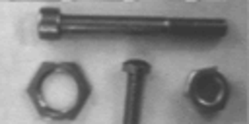

```
Figure 35 - original image of nb.vx
```

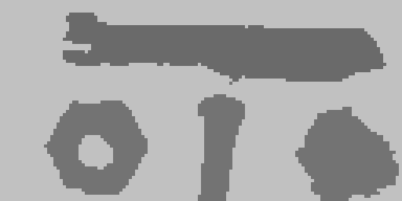

```
Figure 36 - output image of nb.vx from vgrow with range = 77
```

```python
im = Image.open("nb.png")
width, height = im.size
im = im.resize((width*4, height*4))
display(im)
print("Figure 35 - original image of nb.vx \n\n")
im = Image.open("nb-5-77.png")
width, height = im.size
im = im.resize((width*4, height*4))
display(im)
print("Figure 36 - output image of nb.vx from vgrow with range = 77\n\n")
```

The vgrow is executed against Figure 35 and the output is shown in Figure 36. The vgrow is executed with the "-p" flag and the output object region will be represented with the pixel value of each object in the original image. This algorithm starts from the top-left corner and finish to the bottom-right corner. It iterates each pixel and try to group the neighbouring pixels as a single region if it falls within a defined range.

Several runs of trial and errors were done to find the best range to be used for this image. When the range is too small, each object will be represented by several regions and the output will have more than 4 regions. When the range is too big, the objects were not be classified from each other and to number of regions in the image is less than 4.

The ideal range value is found to be 77, in which the objects are well-defined from each other and the background. We can also clearly see the shape of each of the screw and nut. If you take a look at the nut on the bottom-left of the image, we can see the hole in the middle of the nut representing the background. One aspect that this algorithm did poorly is on the region of the nut on the bottom-right, in which the algorithm could not separate the background in the hole of the nut with the nut itself. This is because the shadow in the original image causes the background to be of the same gray value with the nut itself, causing this poor region segmentation. Despite the imperfection, overall this algorithm did really well segmenting this image. The 4 regions or objects are clearly defined from the background and from each other. It looks like a solid algorithm to be used for image segmentation.

Next, this algorithm is executed on the shtl.vx image. This is an image where the thresholding algorithm did so poorly. What makes this iamge tricky to segment is that the background is of a gradient gray values from black to white, and that the main object is of a gray value within the background range. We will be exploring on whether region growing will provide a better performance.

[output not shown]

[figure not shown]

```
Figure 38 - output image of shtl.vx from vgrow with range = 3
```

```python
im = Image.open("shtl.png")
width, height = im.size
im = im.resize((width*2, height*2))
display(im)
print("Figure 37 - original image of shtl.vx \n\n")
im = Image.open("shtl-5-r3.png")
width, height = im.size
im = im.resize((width*2, height*2))
display(im)
print("Figure 38 - output image of shtl.vx from vgrow with range = 3\n\n")
```

Similar to the previous image, the "-p" flag is used so that the output label will represent the pixel value in the original image. A wide value or range is being tested to find the best range that will classify.

The result is that the range of 3 is defined as the best range to be used. However, it actually does not change the original image that much and the result is not meaningful. As seen in the Figure 38, the object is not segmented from the background and the regions produced are not meaningful. Based on the experimentation being done, the region growing does not perform well. What this does is separate this image into diagonal regions of columns that goes from the top-right corner to the bottom-left corner. As the range is increased, the width of each column gets bigger and the number of total regions decreases. However, no matter what range is being used, it cannot produce a meaningful output that shows the objects regions.

Due to the poor performance of vgrow region growing algorithm on the shtl.vx, we will be exploring pre-processing that may help the performance of the vgrow algorithm. The pre-processing that is explored is edge-operator. An edge operator program will output the edge detected image. The "vsobel" command is used to perform sobel edge detection on shtl.vx. The output is named edge.vx.

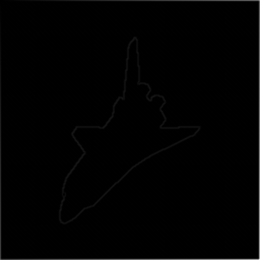

```
Figure 39 -  image edge.vx, the output of image shtl.vx after sobel edge operator
```

[figure not shown]

```
Figure 40 -  image edge.vx, scaled by 5 using vpix command
```

```python
im = Image.open("edge.png")
width, height = im.size
im = im.resize((width*2, height*2))
display(im)
print("Figure 39 -  image edge.vx, the output of image shtl.vx after sobel edge operator\n\n")
im = Image.open("edge-s.png")
width, height = im.size
im = im.resize((width*2, height*2))
display(im)
print("Figure 40 -  image edge.vx, scaled by 5 using vpix command\n\n")
```

After using vsobel command to execute a sobel edge operator on the original shtl.vx image, the output in Figure 39 shows the edge of the shuttle. However, the pixel values of the edges are extremely low that it is difficult to differentiate to the background. A scaled version of the edge.vx is shown in Figure 40, where each pixel is scaled by 5 using vpix point operation command. The goal is to clearly show the edge of the shtl.vx.

After performing this edge operator on shtl.vx image, the vgrow algorithm will be used to segment this image. We will explore on whether this pre-processing helps for vgrow algorithm.

[figure not shown]

```
Figure 41 -  output of image edge.vx after vgrow with range = 21
```

[figure not shown]

```
Figure 42 -  vgrow output of image edge.vx with colored labels
```

```python
im = Image.open("edge-21.png")
width, height = im.size
im = im.resize((width*2, height*2))
display(im)
print("Figure 41 -  output of image edge.vx after vgrow with range = 21 \n\n")
im = Image.open("edge-21-rand.png")
width, height = im.size
im = im.resize((width*2, height*2))
display(im)
print("Figure 42 -  vgrow output of image edge.vx with colored labels \n\n")
```

For this output image shown in Figure 41, the "-p" is not passed to the command. The output image is labeled sequentially. The range value is tested between 1 to 255. When the "r" value is low, between 1 to 20, the performance of the program is poor. The edge of the object is not segmented into a single region. However, starting from "r" to be 21 to 255, the region of the edge of the object is classified really well. The edge is able to be labeled as a single region. The range value of 21 is concluded to be one of the best, as it will classify the edge as a single region with the same label.

If you analyze Figure 41, we can see the tiny arrows in the background of the image. This is because the background of edge.vx is made up of "0" and "1" pixel values and they are detected as different regions. As a result, they are labeled as different regions and causes these tiny arrows visualization.

For visualization purpose, the output is processed using vcmap to uniquely color all regions. From the visualization in Figure 42, we can see that the edge is a single region. We can also see the tons of different regions in the background of the image.

Next, the output image is processsed to make it printable. This is done by running the vpix -neg command, which will revert the gray pixel values.

[figure not shown]

```
Figure 43 -  output of image edge.vx after vgrow with range = 21, with inverted pixel
```

```python
im = Image.open("edge-21-neg.png")
width, height = im.size
im = im.resize((width*2, height*2))
display(im)
print("Figure 43 -  output of image edge.vx after vgrow with range = 21, with inverted pixel \n\n")
```

After this process of reverting the pixel values using vpix command, the edge region can be seen in black in Figure 43.

Concluding the performance of vgrow, it can be clearly seen that after the edge operation is done, the vgrow algorithm perform much better segmenting the shtl.vx image. We can see the major difference on the output images of using the original image vs edge-operated image as inputs. This means that in several cases, such as when an image is like shtl.vx, pre-processing may be required to allow a region-growing algorithm to have a much better performance and to provide a meaningful output.

To summarize this process, what happened is that a sobel edge operator is performed on the shtl.vx image. The output of that is an image with the detected edges of the object. Next, vgrow is used to segment the different regions in the image, using a specified range. With the right range, the region can be segmented in a way that the edge of the object (the shuttle) is of the same region and label. As a result, this process gives a great and meaningful output.

In this lab, we have explored two main image segmentation methods: thresholding and region growing. In thresholding itself, we learned about peakiness detection algorithm and iterative threshold selectrion algorith. For each of the methods, we have learned the strengths and weaknesses. We have also learned that pre-processing like edge detection before image segmentation may be beneficial to improve the output result.